# Common Garden Design

## Intro

Determine randomization strategy and plant placing for 2024 Wrights Lake 2 Planting

```r
library(tidyverse)
library(googlesheets4)
library(ggforce)

is.even <- function(x) x%%2 == 0

popsheet <- "https://docs.google.com/spreadsheets/d/1EhkPTCMpy_hIz2yROdXNtTdh8ljkHjCHnTPdML49MuM"
```

## IMPORTANT

Snaking blocks through the beds really should be done but it is trick to coordinate with the blocked positions from the field. Probably need a new strategy of adding “germinated” plants to the plan. Like arrange the plan3 df in the correct order with the snaking, and then pull in the germinated plants, possible one at a time to fill it up in the correct order. Didn’t happen for 2024.

## get germination data

**Note: be sure to check the checkbox to grant access on the webpage that opens when you run the code below**

parents

```r
parents <- read_sheet(popsheet,
                      sheet = "parents_labels_germ",
                      na=c("NA", "")
) %>%
  filter(germinated.y.n == 1) %>%
  select(unique.ID, rack, pop.id, rep = Rep)
```

```
The googlesheets4 package is requesting access to your Google account.
Enter '1' to start a new auth process or select a pre-authorized account.
1: Send me to the browser for a new auth process.
2: jnmaloof@ucdavis.edu
```

```r
2
```

```
✔ Reading from Summer_24_Planting_Planning.
✔ Range ''parents_labels_germ''.
```

```r
parents
```

| unique.ID | rack | pop.id | rep |
| --- | --- | --- | --- |
| 1 | 1 | LV1 | 1 |
| 2 | 1 | LV1 | 2 |
| 3 | 1 | LV1 | 3 |
| 4 | 1 | LV1 | 4 |
| 5 | 1 | LV1 | 5 |
| 6 | 1 | LV1 | 6 |
| 7 | 1 | LV1 | 7 |
| 8 | 1 | LV1 | 8 |
| 9 | 1 | LV1 | 9 |
| 12 | 1 | LV1 | 12 |

[output cut: 273 more lines]

F1s

```r
F1s <- read_sheet(popsheet,
                  sheet = "F1s_labels_germ",
                  na=c("NA", "")
) %>%
  filter(germinated.y.n == 1) %>%
  select(unique.ID, rack, pop.id, rep=Rep)
```

```
✔ Reading from Summer_24_Planting_Planning.
✔ Range ''F1s_labels_germ''.
```

```r
F1s
```

| unique.ID | rack | pop.id | rep |
| --- | --- | --- | --- |
| 194 | 3 | WV x TM2 | 1 |
| 195 | 3 | WV x TM2 | 2 |
| 196 | 3 | WV x TM2 | 4 |
| 197 | 3 | WV x TM2 | 5 |
| 198 | 3 | WV x TM2 | 6 |
| 199 | 3 | WV x TM2 | 7 |
| 200 | 3 | WV x TM2 | 8 |
| 201 | 3 | WV x TM2 | 9 |
| 202 | 3 | WV x TM2 | 10 |
| 203 | 3 | WV x TM2 | 11 |

[output cut: 100 more lines]

F2s

```r
F2s <- read_sheet(popsheet,
                  sheet = "F2s_labels_germ",
                  na=c("NA", "")
) %>%
  filter(germinated.y.n == 1) %>%
  select(unique.ID, rack, pop.id, rep=Rep)
```

```
✔ Reading from Summer_24_Planting_Planning.
✔ Range ''F2s_labels_germ''.
```

```r
F2s
```

| unique.ID | rack | pop.id | rep |
| --- | --- | --- | --- |
| 64 | 1 | (LV1 x WL2) x (WL2) | 1 |
| 65 | 1 | (LV1 x WL2) x (WL2) | 2 |
| 66 | 1 | (LV1 x WL2) x (WL2) | 3 |
| 67 | 1 | (LV1 x WL2) x (WL2) | 4 |
| 68 | 1 | (LV1 x WL2) x (WL2) | 5 |
| 69 | 1 | (LV1 x WL2) x (WL2) | 6 |
| 70 | 1 | (LV1 x WL2) x (WL2) | 7 |
| 71 | 1 | (LV1 x WL2) x (WL2) | 8 |
| 72 | 1 | (LV1 x WL2) x (WL2) | 9 |
| 73 | 1 | (LV1 x WL2) x (WL2) | 10 |

[output cut: 427 more lines]

```r
# extra plants
# extra <- read_sheet(url,
#                     sheet = "extra plants",
#                     na=c("NA", "")
# )  %>%
#   mutate(across(.cols= c(`dame-mf`, `sire-mf`), .fns = str_remove, "( |-)[^)]*$" ),
#          pop.id = str_c(`dame-mf`, " x ", `sire-mf` ),
#          unique.ID=seq(from=2001, length.out=n()),
#          rack = NaN) %>%
#    select(-`dame-mf`, -`sire-mf`, rep)
#
# extra
```

```r
#combined <- bind_rows(parents, F1s, F2s, extra)
germinated <- bind_rows(parents, F1s, F2s)
germinated
```

| unique.ID | rack | pop.id | rep |
| --- | --- | --- | --- |
| 1 | 1 | LV1 | 1 |
| 2 | 1 | LV1 | 2 |
| 3 | 1 | LV1 | 3 |
| 4 | 1 | LV1 | 4 |
| 5 | 1 | LV1 | 5 |
| 6 | 1 | LV1 | 6 |
| 7 | 1 | LV1 | 7 |
| 8 | 1 | LV1 | 8 |
| 9 | 1 | LV1 | 9 |
| 12 | 1 | LV1 | 12 |

[output cut: 820 more lines]

## assign blocks to germinated

get a histogram of rep count

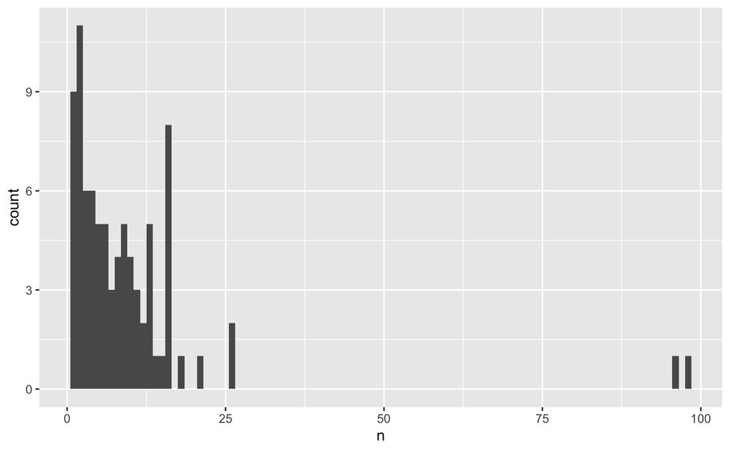

```r
germinated %>%
  group_by(pop.id) %>%
  summarize(n=n()) %>%
  ggplot(aes(x=n)) +
  geom_histogram(binwidth = 1)
```

```r
germinated %>%
  group_by(pop.id) %>%
  summarize(n=n()) %>%
  arrange(n)
```

| pop.id | n |
| --- | --- |
| (DPR x WL2) x (DPR x WL2) | 1 |
| (LV1 x WL2) x (SQ3 x WL2) | 1 |
| (TM2 x WL2) x (DPR x WL2) | 1 |
| (TM2 x WL2) x (LV1 x WL2) | 1 |
| (TM2 x WL2) x (TM2 x BH) | 1 |
| (TM2 x WL2) x (WV x WL2) | 1 |
| (TM2) x (TM2 x BH) | 1 |
| (WL2 x TM2) x (WL2) | 1 |
| TM2 x YO11 | 1 |
| (CC x TM2) x (WL2 x TM2) | 2 |

[output cut: 74 more lines]

A bit challenging because for pops with few reps total we should be careful to distribute the pops across the blocks. Also different max rep sizes: 16 for F2s, 26 for at least a couple of F1s.

Will go for 16 blocks total. That will be one rep per block for fully germinated F2s.

I think one way this can work is to arrange by pops and mfs and then assign a randomized set of block labels to it.

```r
#terminology with "germ" prefix is a leftover from UCD2022 when we planted both germinated and ungerminated seed.

nblocks <- 16

germblocks <- LETTERS[1:nblocks]

germreps <- ceiling(nrow(germinated) / length(germblocks) ) # number of times we have to assign blocks

germinated$block <- rep(germblocks, length.out=nrow(germinated))

#for low rep mfs, randomize all mfs in the pop that have have < nblocks
set.seed(888)
germinated_low_extra_rep <- germinated %>%
 # group_by(pop.id, mf) %>%
  group_by(pop.id) %>%
  mutate(reps=n()) %>%
  filter(reps < 16 | rep > 16) %>% # because nblocks represents full replication.  Pull pops with less than nblocks reps and pull extra reps from those with > nblocks
  group_by(pop.id) %>%
  mutate(block= {map(1:ceiling(n()/nblocks), ~ sample(germblocks)) %>% #sampling without replacement 1 block at a time helps with even distribution across blocks.
      unlist() %>% magrittr::extract(1:n())}, # clean up last rep
  ) %>%
  ungroup()

#For high rep mfs, just use the sequentially assigned blocks
germinated_fullrep <- germinated %>%
  #group_by(pop.id, mf) %>%
  group_by(pop.id) %>%
  mutate(reps=n()) %>%
  filter(reps >= nblocks, rep < nblocks+1) %>% #get those plants corresponding to full germination but not extra
  ungroup()

germinated <- bind_rows(germinated_low_extra_rep, germinated_fullrep) %>%
  #arrange(pop.id, mf)
  arrange(pop.id)

germinated
```

| unique.ID | rack | pop.id | rep | block | reps |
| --- | --- | --- | --- | --- | --- |
| 663 | 8 | (BH) x (TM2 x BH) | 1 | H | 3 |
| 666 | 8 | (BH) x (TM2 x BH) | 4 | A | 3 |
| 678 | 8 | (BH) x (TM2 x BH) | 16 | K | 3 |
| 1430 | 16 | (CC x TM2) x (WL2 x TM2) | 2 | F | 2 |
| 1429 | 16 | (CC x TM2) x (WL2 x TM2) | 1 | I | 2 |
| 1440 | 16 | (DPR x WL2) x (DPR x WL2) | 9 | J | 1 |
| 686 | 8 | (DPR x WL2) x (SQ3 x WL2) | 8 | P | 3 |
| 689 | 8 | (DPR x WL2) x (SQ3 x WL2) | 11 | J | 3 |
| 690 | 8 | (DPR x WL2) x (SQ3 x WL2) | 12 | H | 3 |
| 1445 | 16 | (DPR x WL2) x (TM2 x WL2) | 3 | L | 4 |

[output cut: 820 more lines]

reality check distribution across mfs

```r
# germinated %>%
#   pivot_wider(id_cols = c(pop.id, mf), names_from = block, values_from = `germinated?`, values_fill = 0, values_fn = sum)
```

reality check distribution across pop.ids

```r
germinated %>%
  pivot_wider(id_cols = pop.id, names_from = block, values_from = reps, values_fill = 0, values_fn = sum) %>%
  relocate(germblocks)
```

| A | B | C | D | E | F | G | H | I | J | K | L | M | N | O | P | pop.id |
| --- | --- | --- | --- | --- | --- | --- | --- | --- | --- | --- | --- | --- | --- | --- | --- | --- |
| 3 | 0 | 0 | 0 | 0 | 0 | 0 | 3 | 0 | 0 | 3 | 0 | 0 | 0 | 0 | 0 | (BH) x (TM2 x BH) |
| 0 | 0 | 0 | 0 | 0 | 2 | 0 | 0 | 2 | 0 | 0 | 0 | 0 | 0 | 0 | 0 | (CC x TM2) x (WL2 x TM2) |
| 0 | 0 | 0 | 0 | 0 | 0 | 0 | 0 | 0 | 1 | 0 | 0 | 0 | 0 | 0 | 0 | (DPR x WL2) x (DPR x WL2) |
| 0 | 0 | 0 | 0 | 0 | 0 | 0 | 3 | 0 | 3 | 0 | 0 | 0 | 0 | 0 | 3 | (DPR x WL2) x (SQ3 x WL2) |
| 0 | 0 | 0 | 0 | 0 | 0 | 0 | 0 | 0 | 0 | 0 | 4 | 4 | 4 | 0 | 4 | (DPR x WL2) x (TM2 x WL2) |
| 0 | 6 | 0 | 0 | 6 | 0 | 0 | 6 | 0 | 6 | 0 | 6 | 0 | 6 | 0 | 0 | (DPR x WL2) x (WV x WL2) |
| 0 | 8 | 0 | 0 | 8 | 0 | 0 | 8 | 8 | 0 | 8 | 0 | 8 | 8 | 0 | 8 | (DPR x WL2) x (YO11 x WL2) |
| 0 | 11 | 11 | 11 | 0 | 11 | 0 | 0 | 11 | 11 | 11 | 11 | 11 | 11 | 11 | 0 | (DPR) x (DPR x WL2) |
| 16 | 16 | 16 | 16 | 16 | 16 | 16 | 16 | 16 | 16 | 16 | 16 | 16 | 16 | 16 | 16 | (DPR) x (WL2 x DPR) |
| 0 | 0 | 0 | 0 | 0 | 0 | 3 | 0 | 3 | 0 | 0 | 0 | 0 | 0 | 3 | 0 | (LV1 x WL2) x (LV1 x WL2) |

[output cut: 74 more lines]

plants per block:

```r
germinated %>%
  group_by(block) %>%
  summarise(n=n()) %>% arrange(n)
```

| block | n |
| --- | --- |
| L | 47 |
| M | 47 |
| F | 48 |
| G | 48 |
| C | 50 |
| D | 50 |
| K | 50 |
| P | 50 |
| J | 52 |
| A | 54 |

[output cut: 6 more lines]

## planting grid

Plot is trapezoidal. wide edges are 20m and 16.5m. narrow are 15m and 7.5m .

**numbers below updated to match more precise field measurements**

Try creating rectangular grid and then use blanks to narrow it.

Create grid

```r
stagger <- TRUE
buffer.beds <- 0
buffer.rows <- 2 # on each edge of each bed
exp.beds <- 11
beds <- letters[1:(buffer.beds+exp.beds)]
columns <- 4 # per bed
rows <- 63 # four of which are buffers
plants <- length(beds) * columns * rows
bedwidth <- 90 # cm
furrow <- 100 #cm
size <- 25 # plant diameter
radius <- size/2

plan3 <- expand_grid(bed=beds,
                     column=1:columns,
                     row=1:rows,
                     radius=radius)

plan3 <- plan3 %>%
  mutate(plantedcol=(match(bed, letters)-1)*4 + column,
         bedcol = floor((match(bed, letters)-1) + 1   ))

plan3
```

| bed | column | row | radius | plantedcol | bedcol |
| --- | --- | --- | --- | --- | --- |
| a | 1 | 1 | 12.5 | 1 | 1 |
| a | 1 | 2 | 12.5 | 1 | 1 |
| a | 1 | 3 | 12.5 | 1 | 1 |
| a | 1 | 4 | 12.5 | 1 | 1 |
| a | 1 | 5 | 12.5 | 1 | 1 |
| a | 1 | 6 | 12.5 | 1 | 1 |
| a | 1 | 7 | 12.5 | 1 | 1 |
| a | 1 | 8 | 12.5 | 1 | 1 |
| a | 1 | 9 | 12.5 | 1 | 1 |
| a | 1 | 10 | 12.5 | 1 | 1 |

[output cut: 990 more lines]

add positions

```r
if (stagger) {
  column_offset <- sqrt((2*radius)^2 - radius^2) # Pythagorean theorem for offset spacing
  plan3 <- plan3 %>%
    mutate(y_pos=ifelse(is.even(column),
                        row*size,
                        row*size-radius),
           x_pos=ifelse(column==1,
                        radius+(bedcol-1)*(bedwidth+furrow),
                        radius+(column-1)*column_offset+(bedcol-1)*(bedwidth+furrow)))
} else {
  plan3 <- plan3 %>%
    mutate(y_pos=row*size,
           x_pos=bedcol*(bedwidth+furrow))
}
plan3
```

| bed | column | row | radius | plantedcol | bedcol | y_pos | x_pos |
| --- | --- | --- | --- | --- | --- | --- | --- |
| a | 1 | 1 | 12.5 | 1 | 1 | 12.5 | 12.50000 |
| a | 1 | 2 | 12.5 | 1 | 1 | 37.5 | 12.50000 |
| a | 1 | 3 | 12.5 | 1 | 1 | 62.5 | 12.50000 |
| a | 1 | 4 | 12.5 | 1 | 1 | 87.5 | 12.50000 |
| a | 1 | 5 | 12.5 | 1 | 1 | 112.5 | 12.50000 |
| a | 1 | 6 | 12.5 | 1 | 1 | 137.5 | 12.50000 |
| a | 1 | 7 | 12.5 | 1 | 1 | 162.5 | 12.50000 |
| a | 1 | 8 | 12.5 | 1 | 1 | 187.5 | 12.50000 |
| a | 1 | 9 | 12.5 | 1 | 1 | 212.5 | 12.50000 |
| a | 1 | 10 | 12.5 | 1 | 1 | 237.5 | 12.50000 |

[output cut: 990 more lines]

add indicator for whether or not a position is available and inbounds

```r
bedrows   <- c(63, 61, 60, 59, 53, 47, 45, 34, 24, 20, 16)

plan3 <- plan3 %>%
  mutate(status=ifelse(row <= bedrows[bedcol], "available", "out-of-bounds"))

# eliminate some beds for 2024 because we have fewer plants

plan3 <- plan3 %>%
  mutate(status=ifelse(str_detect(bed, "[abjk]"), "out-of-bounds", status))

# block out tree position (approx)
plan3 <- plan3 %>%
  mutate(status=ifelse(bedcol == 5 & row > bedrows[5] -23 & row <= bedrows[5]-13, "out-of-bounds", status),
         status=ifelse(bedcol == 6 & row > bedrows[6] -19 & row <= bedrows[6]-9, "out-of-bounds", status)
         )

# block out positions with rocks

rocks <- tribble(~bed, ~column, ~row,
                 "a", 1, 44,
                 "a", 2, 44,
                 "a", 3, 45,
                 "a", 3, 45,
                 "a", 2, 48,
                 "a", 4, 48,
                 "b", 1, 35,
                 "c", 4, 3,
                 "c", 4, 4,
                 "c", 1, 9,
                 "c", 3, 26,
                 "c", 4, 26,
                 "c", 3, 27,
                 "c", 4, 27,
                 "c", 1, 33,
                 "c", 3, 45,
                 "c", 3, 46,
                 "d", 2, 5,
                 "d", 1, 6,
                 "d", 3, 6,
                 "d", 4, 6,
                 "d", 1, 7,
                 "d", 2, 7,
                 "d", 4, 7,
                 "d", 2, 8,
                 "d", 1, 12,
                 "d", 2, 34,
                 "d", 3, 37,
                 "e", 1, 6,
                 "e", 2, 9,
                 "e", 2, 13,
                 "e", 4, 15,
                 "e", 4, 16,
                 "e", 1, 30,
                 "e", 2, 30,
                 "e", 3, 30,
                 "e", 4, 30,
                 "f", 2, 5,
                 "f", 3, 6,
                 "f", 4, 17,
                 "f", 4, 18,
                 "f", 2, 40,
                 "g", 3, 23,
                 "g", 4, 22,
                 "g", 4, 23,
                 "i", 1, 3,
                 "i", 3, 4,
                 "i", 4, 5,
                 "k", 3, 5,
                 )

rocks <- bind_rows(rocks,
  tibble(
    bed="h",
    column = c(rep(1,7),
                rep(2,3),
                rep(3, 6),
                rep(4, 3)),
    row = c(9:12, 14:16,
            7, 14, 16,
            4, 5, 7, 14, 16, 17,
            11, 12, 13)
  )
)

rocks <- rocks %>% mutate(new_status="out-of-bounds") %>% arrange(bed, row, column)

plan3 <- left_join(plan3, rocks) %>%
  mutate(status = ifelse(is.na(new_status), status, new_status)) %>%
  select(-new_status)
plan3
```

| bed | column | row | radius | plantedcol | bedcol | y_pos | x_pos | status |
| --- | --- | --- | --- | --- | --- | --- | --- | --- |
| a | 1 | 1 | 12.5 | 1 | 1 | 12.5 | 12.50000 | out-of-bounds |
| a | 1 | 2 | 12.5 | 1 | 1 | 37.5 | 12.50000 | out-of-bounds |
| a | 1 | 3 | 12.5 | 1 | 1 | 62.5 | 12.50000 | out-of-bounds |
| a | 1 | 4 | 12.5 | 1 | 1 | 87.5 | 12.50000 | out-of-bounds |
| a | 1 | 5 | 12.5 | 1 | 1 | 112.5 | 12.50000 | out-of-bounds |
| a | 1 | 6 | 12.5 | 1 | 1 | 137.5 | 12.50000 | out-of-bounds |
| a | 1 | 7 | 12.5 | 1 | 1 | 162.5 | 12.50000 | out-of-bounds |
| a | 1 | 8 | 12.5 | 1 | 1 | 187.5 | 12.50000 | out-of-bounds |
| a | 1 | 9 | 12.5 | 1 | 1 | 212.5 | 12.50000 | out-of-bounds |
| a | 1 | 10 | 12.5 | 1 | 1 | 237.5 | 12.50000 | out-of-bounds |

[output cut: 990 more lines]

Get 2023 plants that are still alive

```r
survey <- read_sheet("https://docs.google.com/spreadsheets/d/1cJE-tR3v4OA5rurcnFU5f1MgtEbxECSre5nzRiVN0-w", na = c("", "NA"),
                     col_types = "ccicciicc") %>%
  filter(str_detect(death.date, "[ABC]"))
```

```
✔ Reading from WL2_status_check_20240603_corrected.
✔ Range WL2_status_check_20240603.
```

```r
survey <- survey %>%
  select(bed, column=`bed- col`, row=`bed- row`)  %>%
  mutate(bed = tolower(bed),
         new_status="2023-survivor",
         column=case_match(column,
                        "A" ~ 1,
                        "B" ~ 2,
                        "C" ~ 3,
                        "D" ~ 4
                        ))

plan3 <- left_join(plan3, survey) %>%
  mutate(status = ifelse(is.na(new_status), status, new_status)) %>%
  select(-new_status)
```

Get 2023 TM2 plants that fruited

```r
annual_census_2023 <- read_csv("~/Library/CloudStorage/GoogleDrive-jnmaloof@ucdavis.edu/Shared drives/IntBioTeam/Common Gardens/WL2_2023/CorrectedCSVs/WL2_annual_census_20231027_corrected.csv", guess_max = 2000) %>%
  filter(pop=="TM2", num.fruit>0) %>%
  select(bed, column=`bed-col`, row=`bed-row`)  %>%
  mutate(bed = tolower(bed),
         new_status="2023-TM2-fruit",
         column=case_match(column,
                        "A" ~ 1,
                        "B" ~ 2,
                        "C" ~ 3,
                        "D" ~ 4
                        ))
plan3 <- left_join(plan3, annual_census_2023) %>%
  mutate(status = ifelse(is.na(new_status), status, new_status)) %>%
  select(-new_status)
```

Add buffers at the beginning and end of each bed

```r
plan3 <- plan3 %>%

  #top buffers:
  mutate(buffer=(row<=3 & str_detect(bed, "[c-h]")) | (row <=2 & str_detect(bed, "i")), # if you want different number of buffers in last row

  #bottom buffers
         buffer=ifelse(row > (bedrows[bedcol]-2) & row <= bedrows[bedcol] & str_detect(bed, "[c-i]"), TRUE, buffer),
         status=ifelse(buffer, "buffer", status)
  )
```

Plot it

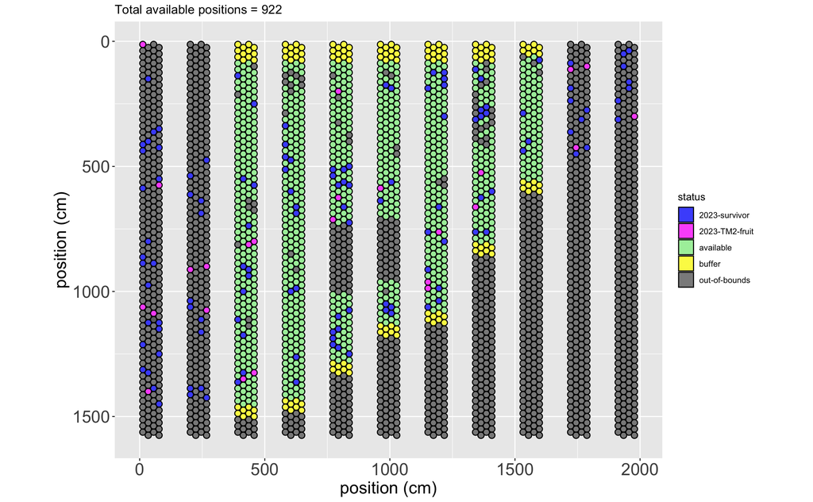

```r
plan3 %>%
  ggplot(aes(x0=x_pos, y0=y_pos, r=radius, fill=status)) +
  geom_circle(alpha=.75) +
  scale_fill_manual(values=c("out-of-bounds"="grey40", "available"="lightgreen", "2023-survivor"="blue", "2023-TM2-fruit"="magenta", "buffer"="yellow")) +
  coord_equal() +
  #  geom_text(aes(x=x_pos, y=y_pos, label=bed), size= 14, data = bed.labels, inherit.aes = FALSE) +
  theme(axis.text = element_text(size=18), axis.title = element_text(size=18)) +
  xlab("position (cm)") + ylab("position (cm)") +
  scale_y_reverse() +
  ggtitle(str_c("Total available positions = ", sum(plan3$status=="available")))
```

```r
ggsave("../output/2024-WL2-FieldPlan.jpeg", width = 10, height = 6)
```

Position blocks in the available spots

```r
blocksizes <- germinated %>%
  group_by(block) %>%
  summarise(n=n()) %>%
  mutate(n=n+4) # a buffer row between blocks

blocks <-rep(blocksizes$block, time=blocksizes$n)

avail <- plan3 %>%
  filter(status=="available") %>%
  arrange(bed, row, column) %>%
  magrittr::extract(1:length(blocks),) %>%
  mutate(block=blocks) %>%
  group_by(block) %>%
  mutate(block.id=str_c(block, str_pad(1:n(), width = 2, pad = "0"))) %>%
  ungroup()
```

## Assign Plants

### germinated

```r
set.seed(999)

germinated <- germinated %>%
  group_by(block) %>%
  slice_sample(n=nrow(.)) %>% # randomize position within blocks
  mutate(block.id=str_c(block, str_pad(1:n(), width = 2, pad = "0"))) %>%
  ungroup() %>%
  arrange(block.id) %>%
  select(-reps)

germinated <- left_join(avail, germinated)
germinated  %>% arrange(block, row, column) %>%
  select(block, row, column, block.id, everything())
```

| block | row | column | block.id | bed | radius | plantedcol | bedcol | y_pos | x_pos | status | buffer | unique.ID | rack | pop.id | rep |
| --- | --- | --- | --- | --- | --- | --- | --- | --- | --- | --- | --- | --- | --- | --- | --- |
| A | 4 | 1 | A01 | c | 12.5 | 9 | 3 | 87.5 | 392.5000 | available | FALSE | 280 | 3 | (WV x WL2) x (WV) | 13 |
| A | 4 | 2 | A02 | c | 12.5 | 10 | 3 | 100.0 | 414.1506 | available | FALSE | 949 | 11 | (LV1 x WL2) x (TM2 x WL2) | 7 |
| A | 4 | 3 | A03 | c | 12.5 | 11 | 3 | 87.5 | 435.8013 | available | FALSE | 987 | 11 | (LV1 x WL2) x (YO11 x WL2) | 2 |
| A | 5 | 1 | A04 | c | 12.5 | 9 | 3 | 112.5 | 392.5000 | available | FALSE | 540 | 6 | TM2 | 70 |
| A | 5 | 2 | A05 | c | 12.5 | 10 | 3 | 125.0 | 414.1506 | available | FALSE | 317 | 4 | (TM2 x WL2) x (SQ3 x WL2) | 13 |
| A | 5 | 3 | A06 | c | 12.5 | 11 | 3 | 112.5 | 435.8013 | available | FALSE | 666 | 8 | (BH) x (TM2 x BH) | 4 |
| A | 5 | 4 | A07 | c | 12.5 | 12 | 3 | 125.0 | 457.4519 | available | FALSE | 87 | 1 | (SQ3 x WL2) x (WL2) | 8 |
| A | 6 | 2 | A08 | c | 12.5 | 10 | 3 | 150.0 | 414.1506 | available | FALSE | 1175 | 13 | (WL2 x BH) x (SQ3 x WL2) | 14 |
| A | 6 | 3 | A09 | c | 12.5 | 11 | 3 | 137.5 | 435.8013 | available | FALSE | 1227 | 14 | LV1 x TM2 | 3 |
| A | 6 | 4 | A10 | c | 12.5 | 12 | 3 | 150.0 | 457.4519 | available | FALSE | 1185 | 13 | (WL2 x CC) x (WL2 x TM2) | 8 |

[output cut: 884 more lines]

```r
germinated  %>% arrange(pop.id) %>%# confirm different positions per block
  select(block, bed, row, column, pop.id)
```

| block | bed | row | column | pop.id |
| --- | --- | --- | --- | --- |
| A | c | 5 | 3 | (BH) x (TM2 x BH) |
| H | e | 11 | 3 | (BH) x (TM2 x BH) |
| K | f | 43 | 1 | (BH) x (TM2 x BH) |
| F | d | 39 | 4 | (CC x TM2) x (WL2 x TM2) |
| I | e | 25 | 1 | (CC x TM2) x (WL2 x TM2) |
| J | f | 11 | 3 | (DPR x WL2) x (DPR x WL2) |
| H | e | 16 | 1 | (DPR x WL2) x (SQ3 x WL2) |
| J | f | 15 | 4 | (DPR x WL2) x (SQ3 x WL2) |
| P | i | 14 | 2 | (DPR x WL2) x (SQ3 x WL2) |
| L | g | 16 | 1 | (DPR x WL2) x (TM2 x WL2) |

[output cut: 884 more lines]

Fill in the blanks..

```r
# germ.fill <- germinated %>%
#   group_by(block) %>%
# #  expand(row=1:max(row), column) #no end buffer rows.  But should fill ragged edges.
#    expand(row=1:max(row+1), column) # use this if you want buffer rows at the end of each bed
#
# germinated <- germ.fill %>%
#   left_join(germinated) %>%
#   mutate(pop.id=ifelse(is.na(pop.id), "buffer", pop.id))
#
# germinated
```

### Correct positions for field mistakes / swaps

```r
## not updated for 2023 WL2
# # Fix replacement made in screenhouse:
# cor1 <- plants %>% filter(parent.pop=="YO8" & mf==7 & rep==12) %>%
#   mutate(parent.pop="SQ3", mf=2, rep=14)
#
# corrected <- plants %>%
#   rows_update(cor1, by=c("block", "row", "column"))
#
# # Fix swaps made while planting
#
# cor2 <- plants %>% filter((parent.pop=="YO8" & mf==2 & rep==8) |( parent.pop=="FR" & mf==5 & rep==1)) %>%
#   mutate(row=rev(row))
#
# cor3 <- plants %>% filter((parent.pop=="YO7" & mf==4 & rep==5) | (parent.pop=="TM2" & mf==7 & rep==9)) %>%
#   mutate(row=rev(row), column=rev(column))
#
# cor4 <- plants %>% filter((parent.pop=="SQ2" & mf==1 & rep==6) | (parent.pop=="LV1" & mf==1 & rep==6)) %>%
#   mutate(row=rev(row), column=rev(column))
#
# cor5 <- plants %>% filter((parent.pop=="YO4" & mf==3 & rep==12) | (parent.pop=="LV1" & mf==7 & rep==10)) %>%
#   mutate(row=rev(row), column=rev(column))
#
# corrected <- corrected %>%
#   rows_update(bind_rows(cor2, cor3, cor4, cor5), by=c("parent.pop", "mf", "rep"))
#
# # Fix Bed K block swaps
#
# cor6 <- plants %>% filter(block=="K2" & row > 22 & row < 37) %>%
#   mutate(block="K1", row=row-22)
#
# cor7 <- plants %>% filter(block=="K1" & row < 15) %>%
#   mutate(block="K2", row=row+22)
#
# corrected <- corrected %>%
#   rows_update(bind_rows(cor6,cor7), by=c("parent.pop", "mf", "rep"))
#
# plants <- corrected
#
# plants %>% arrange(parent.pop, mf, rep) %>%
#   select(parent.pop, mf, rep, bed, block, row, column, everything() ) %>% write_sheet("https://docs.google.com/spreadsheets/d/1EaSA2QrlWAjFR35pedcvheQp3X7Agsla6pZtE2C1QJ4",
#                                                         sheet="Corrected Bed Map 2022-12-06")
```

## combine bed map and field map

first get block rows correct and write to gsheets

```r
germinated %>% arrange(rack, unique.ID) %>%
  select(rack, unique.ID, pop.id, rep, block, blockrow, blockcolumn ) %>%
  write_sheet(popsheet,
              sheet="Randomization Map")
```

```
✔ Writing to Summer_24_Planting_Planning.
✔ Writing to sheet Randomization Map.
```

```r
plan3_plants %>% arrange(pop.id, rep) %>%
  select(pop.id, rep, everything() ) %>%
  write_sheet(popsheet,
              sheet="Buffer New Bed Map")
```

```
✔ Writing to Summer_24_Planting_Planning.
✔ Writing to sheet Buffer New Bed Map.
```

```r
pdf("../output/2024-WL2-planting_maps.pdf",width = 8.5, height = 11)

colors=c("grey40", "yellow", "blue", "magenta", rep(c("orange", "skyblue", "green"), length.out=length(germblocks))) %>%
  set_names("out-of-bounds", "buffer", "2023-survivor", "2023-TM2-fruit", germblocks)


for(b in unique(plan3_plants$bed)) {
  pl1 <- plan3_plants %>% filter(bed==b, bedrow<33) %>%
    ggplot(aes(x0=x_pos, y0=y_pos, r=radius, label=label, fill=colorblock)) +
    scale_fill_manual(values=colors) +
    geom_circle(alpha=.5, color="grey70") +
    geom_text(aes(x=x_pos, y=y_pos), size=3, lineheight=.8) +
    theme(axis.text.x = element_text(angle=90, size=12, vjust = 0.5)) +
    xlab("position (cm)") + ylab("position (cm)") +
    scale_y_reverse() +
    coord_equal(ratio=.4) +
    ggtitle(str_c("Bed ", b, ", sheet 1"))
  print(pl1)
  pl2 <- plan3_plants %>% filter(bed==b, bedrow>=33) %>%
    ggplot(aes(x0=x_pos, y0=y_pos, r=radius, label=label, fill=colorblock)) +
    scale_fill_manual(values=colors) +
    geom_circle(alpha=.5, color="grey70") +
    geom_text(aes(x=x_pos, y=y_pos), size=3, lineheight=.8) +
    theme(axis.text.x = element_text(angle=90, size=12, vjust = 0.5)) +
    xlab("position (cm)") + ylab("position (cm)") +
    scale_y_reverse() +
    coord_equal(ratio=.4) +
    ggtitle(str_c("Bed ", b, ", sheet 2"))
  print(pl2)
}

dev.off()
```

Randomization maps

```r
pdf("../output/2024-WL2-randomization_maps.pdf",width = 8.5, height = 11)

germinated <- germinated %>% arrange(block, blockrow, blockcolumn)

for(b in unique(germinated$block)) {
  pl <- germinated %>% filter(block==b) %>%
#    mutate(label=ifelse(parent.pop=="buffer", "buff", str_c(parent.pop, "\n", mf, "-", rep) )) %>%
    mutate(label=ifelse(pop.id=="buffer", "buff", unique.ID)) %>%
    mutate(label=ifelse(is.na(label), "buff", label)) %>%
    ggplot() +
    geom_label(aes(x=blockcolumn, y=blockrow, label=label), size=3, lineheight=.8) +
    theme(axis.text = element_text(size=12)) +
    scale_y_reverse(breaks = 1:31) +
    scale_x_discrete(position = "top") +
    ggtitle(str_c("Block ", b)) +
    coord_equal(ratio=.5)
  print(pl)
}

dev.off()
```